# The Christmas Premium

## What London's Airbnb data reveals about the world's most

famous festive city and exactly how much the magic costs

London at Christmas is not a marketing campaign. It is a cultural export. The lights on Oxford Street. The markets in Hyde Park and South Bank. The ice rinks outside Somerset House and the Natural History Museum. Every year, millions of people from every corner of the world put London in December on their list and the city's short term rental market prices accordingly.

This project uses Inside Airbnb listing data across London's neighbourhoods alongside Google Trends search interest for "London Christmas" to answer the question every traveller has asked and every hospitality brand wants to know: how much does the Christmas premium actually cost, where does it land hardest, and which neighbourhoods are quietly extracting the most value from the world's collective festive imagination?

The data does not care about the fairy lights. But it noticed them.

**Dataset 1:** Inside Airbnb London Listings, September 2025 **Dataset 2:** Google Trends, "London Christmas" 2020-2025 **Tools:** Python · pandas · Plotly · Tableau Public **Analyst:** Trupthi Raj

```python
import pandas as pd
import numpy as np
import plotly.express as px
import plotly.graph_objects as go
from plotly.subplots import make_subplots
import os
import warnings
warnings.filterwarnings('ignore')

pd.set_option('display.max_columns', None)
pd.set_option('display.float_format', '{:,.2f}'.format)
os.makedirs('charts', exist_ok=True)

# === LOAD LISTINGS ===
df_listings = pd.read_csv('data/listings.csv')
print(f"Listings: {df_listings.shape[0]:,} rows x {df_listings.shape[1]} columns")
print(f"\nColumns: {list(df_listings.columns)}")
print(f"\nFirst look:")
print(df_listings.head(3))

# === LOAD NEIGHBOURHOODS ===
df_neighbourhoods = pd.read_csv('data/neighbourhoods.csv')
print(f"\n\nNeighbourhoods: {df_neighbourhoods.shape}")
print(df_neighbourhoods.head(10))

# === LOAD GOOGLE TRENDS ===
df_trends = pd.read_csv('data/london_christmas.csv', skiprows=1)
df_trends.columns = ['Month', 'Interest']
df_trends['Month'] = pd.to_datetime(df_trends['Month'])
df_trends['Interest'] = pd.to_numeric(df_trends['Interest'], errors='coerce')
df_trends = df_trends[df_trends['Month'] >= '2020-01-01'].copy()
print(f"\n\nGoogle Trends: {len(df_trends)} rows")
print(df_trends.head(5))
```

```
Listings: 96,871 rows x 18 columns

Columns: ['id', 'name', 'host_id', 'host_name', 'neighbourhood_group', 'neighbourhood', 'latitude', 'longitude', 'room_type', 'price', 'minimum_nights', 'number_of_reviews', 'last_review', 'reviews_per_month', 'calculated_host_listings_count', 'availability_365', 'number_of_reviews_ltm', 'license']

First look:
      id                                              name  host_id host_name  \
0  13913               Holiday London DB Room Let-on going    54730     Alina
1  15400               Bright Chelsea  Apartment. Chelsea!    60302  Philippa
2  17402  Very Central Modern 3-Bed/2 Bath By Oxford St W1    67564       Liz

   neighbourhood_group           neighbourhood  latitude  longitude  \
0                  NaN               Islington     51.57      -0.11
1                  NaN  Kensington and Chelsea     51.49      -0.17
2                  NaN             Westminster     51.52      -0.14

         room_type  price  minimum_nights  number_of_reviews last_review  \
0     Private room  70.00               1                 55  2025-08-21
1  Entire home/apt 149.00               4                 97  2025-04-05
2  Entire home/apt 411.00               3                 56  2024-02-19

   reviews_per_month  calculated_host_listings_count  availability_365  \
0               0.30                               2               331
1               0.51                               1               199
2               0.32                               2                80

   number_of_reviews_ltm  license
0                     10      NaN
1                      1      NaN
2                      0      NaN


Neighbourhoods: (33, 2)
   neighbourhood_group         neighbourhood
0                  NaN  Barking and Dagenham
1                  NaN                Barnet
2                  NaN                Bexley
3                  NaN                 Brent
4                  NaN               Bromley
5                  NaN                Camden
6                  NaN        City of London
7                  NaN               Croydon
8                  NaN                Ealing
9                  NaN               Enfield


Google Trends: 72 rows
       Month  Interest
0 2020-01-01         5
1 2020-02-01         2
2 2020-03-01         2
3 2020-04-01         2
4 2020-05-01         2
```

```python
# === DATA QUALITY CHECK ===

print("=== LISTINGS DATASET ===")
print(f"\nRoom type breakdown:")
print(df_listings['room_type'].value_counts())

print(f"\nNeighbourhood breakdown (top 10 by listings):")
print(df_listings['neighbourhood'].value_counts().head(10))

print(f"\nPrice range:")
print(f"Min: £{df_listings['price'].min():,.2f}")
print(f"Max: £{df_listings['price'].max():,.2f}")
print(f"Median: £{df_listings['price'].median():,.2f}")
print(f"Mean: £{df_listings['price'].mean():,.2f}")

print(f"\nMissing values:")
print(df_listings.isnull().sum())

print(f"\nAvailability range:")
print(f"Min: {df_listings['availability_365'].min()} days")
print(f"Max: {df_listings['availability_365'].max()} days")
print(f"Mean: {df_listings['availability_365'].mean():.0f} days")

print(f"\nMinimum nights range:")
print(f"Min: {df_listings['minimum_nights'].min()} nights")
print(f"Max: {df_listings['minimum_nights'].max()} nights")
print(f"Median: {df_listings['minimum_nights'].median()} nights")

print("\n=== GOOGLE TRENDS ===")
print(f"\nPeak interest month:")
peak = df_trends.loc[df_trends['Interest'].idxmax()]
print(f"{peak['Month'].strftime('%B %Y')}: {peak['Interest']}")

print(f"\nAverage interest by month of year:")
df_trends['month_num'] = df_trends['Month'].dt.month
monthly_avg = df_trends.groupby('month_num')['Interest'].mean().round(1)
month_names = {1:'Jan',2:'Feb',3:'Mar',4:'Apr',5:'May',6:'Jun',
               7:'Jul',8:'Aug',9:'Sep',10:'Oct',11:'Nov',12:'Dec'}
monthly_avg.index = monthly_avg.index.map(month_names)
print(monthly_avg)
```

```
=== LISTINGS DATASET ===

Room type breakdown:
room_type
Entire home/apt    62907
Private room       33643
Shared room          212
Hotel room           109
Name: count, dtype: int64

Neighbourhood breakdown (top 10 by listings):
neighbourhood
Westminster               11385
Tower Hamlets              7469
Camden                     6551
Kensington and Chelsea     6401
Hackney                    6359
Southwark                  5475
Lambeth                    5190
Islington                  5036
Wandsworth                 4965
Hammersmith and Fulham     4157
Name: count, dtype: int64

Price range:
Min: £7.00
Max: £1,085,147.00
Median: £135.00
Mean: £229.92

Missing values:
id                                    0
name                                  0
host_id                               0
host_name                            43
neighbourhood_group               96871
neighbourhood                         0
latitude                              0
longitude                             0
room_type                             0
```

[output cut: 26 more lines]

```
Average interest by month of year:
month_num
Jan    4.20
Feb    1.80
Mar    1.80
Apr    2.00
May    2.00
Jun    2.50
Jul    3.20
Aug    6.30
Sep   11.80
Oct   19.00
Nov   42.80
Dec   60.00
Name: Interest, dtype: float64
```

```python
# === DATA CLEANING ===

# Step 1 — Remove missing prices
df_listings = df_listings[df_listings['price'].notna()].copy()
print(f"After removing missing prices: {len(df_listings):,} rows")

# Step 2 — Remove price outliers
# Keep listings between £10 and £5,000 per night
df_listings = df_listings[
    (df_listings['price'] >= 10) &
    (df_listings['price'] <= 5000)
].copy()
print(f"After removing price outliers: {len(df_listings):,} rows")

# Step 3 — Remove extreme minimum nights
# Keep listings with minimum nights of 30 or less
df_listings = df_listings[
    df_listings['minimum_nights'] <= 30
].copy()
print(f"After removing extreme minimum nights: {len(df_listings):,} rows")

# Step 4 — Keep only Entire home and Private room
# Drop Shared room and Hotel room — too few and not relevant
df_listings = df_listings[
    df_listings['room_type'].isin(['Entire home/apt', 'Private room'])
].copy()
print(f"After keeping relevant room types: {len(df_listings):,} rows")

# Step 5 — Add price bands
def price_band(price):
    if price < 100:
        return 'Budget (under £100)'
    elif price < 200:
        return 'Mid-range (£100-£200)'
    elif price < 350:
        return 'Premium (£200-£350)'
    else:
        return 'Luxury (£350+)'

df_listings['price_band'] = df_listings['price'].apply(price_band)

# Step 6 — Add availability category
def availability_category(days):
    if days < 60:
        return 'Low availability'
    elif days < 180:
        return 'Moderate availability'
    else:
        return 'High availability'

df_listings['availability_category'] = df_listings[
    'availability_365'].apply(availability_category)

# Step 7 — Reset index
df_listings.reset_index(drop=True, inplace=True)

# Step 8 — Add Christmas season flag to Google Trends
df_trends['season'] = df_trends['Month'].dt.month.map({
    12: 'Christmas', 11: 'Pre-Christmas', 10: 'Early Build',
    1: 'Off-Season', 2: 'Off-Season', 3: 'Off-Season',
    4: 'Off-Season', 5: 'Off-Season', 6: 'Off-Season',
    7: 'Summer', 8: 'Summer', 9: 'Pre-Build'
})

print("\n=== CLEANING COMPLETE ===")
print(f"\nFinal listings: {len(df_listings):,}")
print(f"\nPrice band breakdown:")
print(df_listings['price_band'].value_counts())
print(f"\nRoom type breakdown:")
print(df_listings['room_type'].value_counts())
print(f"\nAverage price by neighbourhood (top 10):")
print(df_listings.groupby('neighbourhood')['price'].mean().sort_values(
    ascending=False).head(10).round(2))
```

```
After removing missing prices: 61,963 rows
After removing price outliers: 61,855 rows
After removing extreme minimum nights: 61,036 rows
After keeping relevant room types: 60,777 rows

=== CLEANING COMPLETE ===

Final listings: 60,777

Price band breakdown:
price_band
Budget (under £100)      21519
Mid-range (£100-£200)    21228
Premium (£200-£350)      11617
Luxury (£350+)            6413
Name: count, dtype: int64

Room type breakdown:
room_type
Entire home/apt    41593
Private room       19184
Name: count, dtype: int64

Average price by neighbourhood (top 10):
neighbourhood
City of London           336.94
Kensington and Chelsea   311.07
Westminster              309.01
Camden                   206.00
Hammersmith and Fulham   195.56
Wandsworth               186.99
Richmond upon Thames     184.19
Islington                178.33
Tower Hamlets            164.72
Southwark                160.94
Name: price, dtype: float64
```

## The London Airbnb Landscape

Before the Christmas premium can be measured, the baseline needs to be understood. London's short term rental market is not one market. It is thirty three micro-markets wearing the same postcode system, each with its own pricing logic, its own demand profile, and its own relationship with the kind of traveller who chooses Airbnb over a hotel.

This first analysis maps the full landscape. Every borough. Every price point. The foundation that every subsequent finding builds on.

```
Neighbourhood summary:
         neighbourhood  avg_price  median_price  listing_count  avg_availability
               Croydon      96.17         72.00           1170            246.72
                Sutton      96.89         72.50            360            230.39
  Barking and Dagenham     107.32         82.00            538            257.87
            Hillingdon     109.01         70.00            709            267.99
                Harrow     109.44         75.50            456            240.58
               Enfield     113.05         79.00            655            239.49
        Waltham Forest     116.49         92.00           1189            210.19
              Lewisham     117.38         94.00           1519            217.62
                Bexley     119.81         70.00            491            267.11
               Bromley     120.01         90.00            647            243.72
                Ealing     125.20         90.00           1578            227.66
             Redbridge     128.09         78.00            717            260.45
              Havering     129.70         83.00            428            262.10
              Haringey     135.21        100.00           1476            206.30
              Hounslow     136.87         95.00            869            227.77
  Kingston upon Thames     137.21        100.00            478            224.36
                Barnet     139.06        107.00           1715            230.08
                Newham     145.30        118.50           1628            224.57
             Greenwich     146.80        113.00           1321            230.12
                Merton     146.94        110.00            961            219.62
                 Brent     151.71        108.00           2037            206.48
               Hackney     155.10        125.50           3122            194.73
               Lambeth     156.07        114.00           2763            199.56
             Southwark     160.94        122.00           3163            207.02
         Tower Hamlets     164.72        128.00           4159            204.68
             Islington     178.33        140.00           2712            195.71
  Richmond upon Thames     184.19        130.50            800            204.55
            Wandsworth     186.99        140.00           2970            207.67
Hammersmith and Fulham     195.56        144.00           2622            204.18
                Camden     206.00        161.00           4219            205.86
           Westminster     309.01        220.00           8224            211.59
Kensington and Chelsea     311.07        225.00           4654            206.00
        City of London     336.94        248.00            427            258.72

Neighbourhood summary saved for Tableau.
```

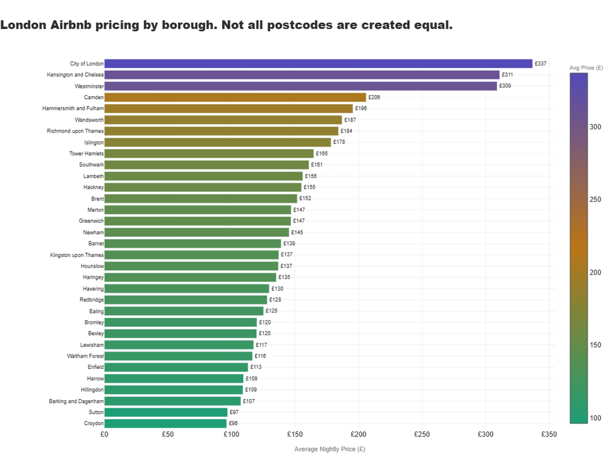

```
Chart 1 saved.
```

```python
# === CHART 1: NEIGHBOURHOOD PRICE MAP ===

neighbourhood_summary = df_listings.groupby('neighbourhood').agg(
    avg_price      = ('price', 'mean'),
    median_price   = ('price', 'median'),
    listing_count  = ('price', 'count'),
    avg_availability = ('availability_365', 'mean')
).reset_index().round(2)

neighbourhood_summary = neighbourhood_summary.sort_values(
    'avg_price', ascending=True)

print("Neighbourhood summary:")
print(neighbourhood_summary.to_string(index=False))

# Save for Tableau
neighbourhood_summary.to_csv('data/neighbourhood_summary.csv', index=False)
print("\nNeighbourhood summary saved for Tableau.")

# === PLOTLY CHART ===
fig = go.Figure()

fig.add_trace(go.Bar(
    x=neighbourhood_summary['avg_price'],
    y=neighbourhood_summary['neighbourhood'],
    orientation='h',
    marker=dict(
        color=neighbourhood_summary['avg_price'],
        colorscale=[
            [0.0, '#1D9E75'],
            [0.5, '#BA7517'],
            [1.0, '#534AB7']
        ],
        showscale=True,
        colorbar=dict(
            title=dict(
                text='Avg Price (£)',
                font=dict(size=10, color='#888780')
            )
        )
    ),
    text=[f"£{v:,.0f}" for v in neighbourhood_summary['avg_price']],
    textposition='outside',
    textfont=dict(size=9, family='Arial'),
    hovertemplate=(
        "<b>%{y}</b><br>"
        "Avg Price: £%{x:,.0f}<br>"
        "<extra></extra>"
    )
))

fig.update_layout(
    title=dict(
        text='London Airbnb pricing by borough. Not all postcodes are created equal.',
        font=dict(size=20, color='#2d2d2d', family='Arial Black'),
        x=0, pad=dict(b=20)
    ),
    xaxis=dict(
        title=dict(
            text='Average Nightly Price (£)',
            font=dict(size=11, color='#888780')
        ),
        gridcolor='#f0f0f0',
        tickprefix='£'
    ),
    yaxis=dict(
        gridcolor='#f0f0f0',
        tickfont=dict(size=9, family='Arial')
    ),
    plot_bgcolor='white',
    paper_bgcolor='white',
    height=800,
    margin=dict(l=180, r=80, t=100, b=60),
    font=dict(family='Arial', color='#2d2d2d'),
    hoverlabel=dict(
        bgcolor='grey',
        bordercolor='#f0f0f0',
        font=dict(size=12, family='Arial'),
        namelength=-1
    )
)

fig.write_html('charts/chart1_neighbourhood_prices.html')
fig.write_image('charts/chart1_neighbourhood_prices.png',
                width=1200, height=800, scale=2)
fig.show()
print("Chart 1 saved.")
```

## The Room Type Premium

Not all listings in the same borough are created equal. A private room in Westminster and an entire apartment in Westminster are two completely different products at two completely different price points targeting two completely different travellers. The room type split matters because it tells you something about who each borough is actually serving and at what price point the Christmas visitor is making their decision.

London's Airbnb market splits roughly 68% entire homes to 32% private rooms after cleaning. But that split is not uniform across boroughs. Inner London skews heavily toward entire homes because the traveller profile is wealthier and the minimum stay requirements are longer. Outer London has a higher proportion of private rooms because the host profile is more casual and the price sensitivity of the guest is higher.

The chart below shows average pricing by room type across every borough. The gap between entire home and private room pricing in each borough is the measure of how polarised each local market actually is.

```
Room type summary saved for Tableau.
```

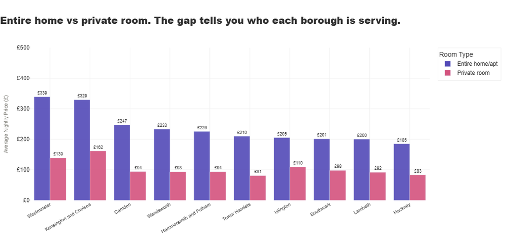

```
Chart 2 saved.
```

```python
# === CHART 2: ROOM TYPE PREMIUM ===

room_neighbourhood = df_listings.groupby(
    ['neighbourhood', 'room_type']).agg(
    avg_price    = ('price', 'mean'),
    listing_count = ('price', 'count')
).reset_index().round(2)

# Save for Tableau
room_neighbourhood.to_csv('data/room_type_summary.csv', index=False)
print("Room type summary saved for Tableau.")

# Top 10 boroughs by listing count for cleaner chart
top_boroughs = df_listings['neighbourhood'].value_counts().head(10).index.tolist()

room_top = room_neighbourhood[
    room_neighbourhood['neighbourhood'].isin(top_boroughs)].copy()

colors = {
    'Entire home/apt': '#534AB7',
    'Private room'   : '#D4537E'
}

fig = go.Figure()

for room_type in ['Entire home/apt', 'Private room']:
    data = room_top[room_top['room_type'] == room_type].sort_values(
        'avg_price', ascending=False)

    fig.add_trace(go.Bar(
        name=room_type,
        x=data['neighbourhood'],
        y=data['avg_price'],
        marker=dict(color=colors[room_type], opacity=0.9),
        text=[f"£{v:,.0f}" for v in data['avg_price']],
        textposition='outside',
        textfont=dict(size=9, family='Arial'),
        hovertemplate=(
            f"<b>{room_type}</b><br>"
            "Borough: %{x}<br>"
            "Avg Price: £%{y:,.0f}<extra></extra>"
        )
    ))

fig.update_layout(
    title=dict(
        text='Entire home vs private room. The gap tells you who each borough is serving.',
        font=dict(size=20, color='#2d2d2d', family='Arial Black'),
        x=0, pad=dict(b=20)
    ),
    barmode='group',
    xaxis=dict(
        gridcolor='#f0f0f0',
        tickfont=dict(size=10, family='Arial'),
        tickangle=-30
    ),
    yaxis=dict(
        title=dict(
            text='Average Nightly Price (£)',
            font=dict(size=11, color='#888780')
        ),
        gridcolor='#f0f0f0',
        tickprefix='£',
        range=[0, 500]
    ),
    plot_bgcolor='white',
    paper_bgcolor='white',
    height=520,
    margin=dict(l=60, r=40, t=100, b=100),
    font=dict(family='Arial', color='#2d2d2d'),
    legend=dict(
        title='Room Type',
        bordercolor='#f0f0f0',
        borderwidth=1
    ),
    hoverlabel=dict(
        bgcolor='grey',
        bordercolor='#f0f0f0',
        font=dict(size=12, family='Arial'),
        namelength=-1
    )
)

fig.write_html('charts/chart2_room_type_premium.html')
fig.write_image('charts/chart2_room_type_premium.png',
                width=1200, height=520, scale=2)
fig.show()
print("Chart 2 saved.")
```

## The Christmas Search Signal

The world starts thinking about Christmas in London in August. Not December. Not even November. August. When the average person is sitting on a beach somewhere, half their brain is already calculating whether this is the year they finally do the Winter Wonderland, the Somerset House ice rink, the Kew Gardens lights. The Google Trends data caught it.

This is not a spike. It is a build. A four month acceleration that the short term rental market prices into every listing in every borough whether the host consciously thinks about it or not. The search interest is the demand signal. The pricing data is the supply response. The chart below shows exactly when the world decides it wants to be in London for Christmas and how consistently that decision has been made year after year.

[figure not shown]

```
Chart 3 saved.
```

```python
# === CHART 3: THE CHRISTMAS SEARCH SIGNAL ===

df_trends['year'] = df_trends['Month'].dt.year
df_trends['month_num'] = df_trends['Month'].dt.month
df_trends['month_name'] = df_trends['Month'].dt.strftime('%b')

# Colour per year
year_colors = {
    2020: '#888780',
    2021: '#BA7517',
    2022: '#1D9E75',
    2023: '#D4537E',
    2024: '#534AB7',
    2025: '#FF6B6B'
}

fig = go.Figure()

# Add each year as a separate line
for year in sorted(df_trends['year'].unique()):
    year_data = df_trends[df_trends['year'] == year].copy()
    year_data = year_data.sort_values('month_num')

    fig.add_trace(go.Scatter(
        x=year_data['month_num'],
        y=year_data['Interest'],
        mode='lines+markers',
        name=str(year),
        line=dict(color=year_colors.get(year, '#888780'), width=2),
        marker=dict(size=6, color=year_colors.get(year, '#888780')),
        hovertemplate=(
            f"<b>{year}</b><br>"
            "Month: %{x}<br>"
            "Interest: %{y}<extra></extra>"
        )
    ))

# Add average line
monthly_avg = df_trends.groupby('month_num')['Interest'].mean().reset_index()

fig.add_trace(go.Scatter(
    x=monthly_avg['month_num'],
    y=monthly_avg['Interest'],
    mode='lines',
    name='5-year average',
    line=dict(color='#2d2d2d', width=3, dash='dash'),
    hovertemplate=(
        "<b>5-year average</b><br>"
        "Month: %{x}<br>"
        "Interest: %{y:.1f}<extra></extra>"
    )
))

# Add Christmas shading
fig.add_vrect(
    x0=10.5, x1=12.5,
    fillcolor='rgba(83,74,183,0.05)',
    line_width=0,
    annotation_text='Peak Season',
    annotation_position='top left',
    annotation_font=dict(size=10, color='#534AB7')
)

fig.update_layout(
    title=dict(
        text='The world starts thinking about Christmas in London in August.',
        font=dict(size=20, color='#2d2d2d', family='Arial Black'),
        x=0, pad=dict(b=20)
    ),
    xaxis=dict(
        title=dict(
            text='Month',
            font=dict(size=11, color='#888780')
        ),
        gridcolor='#f0f0f0',
        tickmode='array',
        tickvals=list(range(1, 13)),
        ticktext=['Jan', 'Feb', 'Mar', 'Apr', 'May', 'Jun',
                  'Jul', 'Aug', 'Sep', 'Oct', 'Nov', 'Dec']
    ),
    yaxis=dict(
        title=dict(
            text='Google Trends Interest (0-100)',
            font=dict(size=11, color='#888780')
        ),
        gridcolor='#f0f0f0',
        range=[0, 110]
    ),
    plot_bgcolor='white',
    paper_bgcolor='white',
    height=500,
    margin=dict(l=60, r=40, t=100, b=60),
    font=dict(family='Arial', color='#2d2d2d'),
    legend=dict(
        title='Year',
        bordercolor='#f0f0f0',
        borderwidth=1
    ),
    hoverlabel=dict(
        bgcolor='grey',
        bordercolor='#f0f0f0',
        font=dict(size=12, family='Arial'),
        namelength=-1
    )
)

fig.write_html('charts/chart3_christmas_signal.html')
fig.write_image('charts/chart3_christmas_signal.png',
                width=1200, height=500, scale=2)
fig.show()
print("Chart 3 saved.")
```

## The Scarcity Premium

Price tells you what a host thinks their listing is worth. Availability tells you whether the market agrees. A listing priced at £400 per night with 300 days of availability is a listing the market has not validated. A listing priced at £400 with 30 days of availability is a listing that sells itself.

The relationship between price and availability is where the Christmas premium becomes most visible. The boroughs that combine high pricing with low availability are the ones where demand structurally exceeds supply. These are not just expensive boroughs. They are boroughs where the expensive listings are actually being booked.

For a Christmas traveller trying to find somewhere to stay in London in December, this chart is the most useful thing in this analysis. It shows not just where is expensive but where is expensive and full. Those are two very different problems requiring two very different solutions.

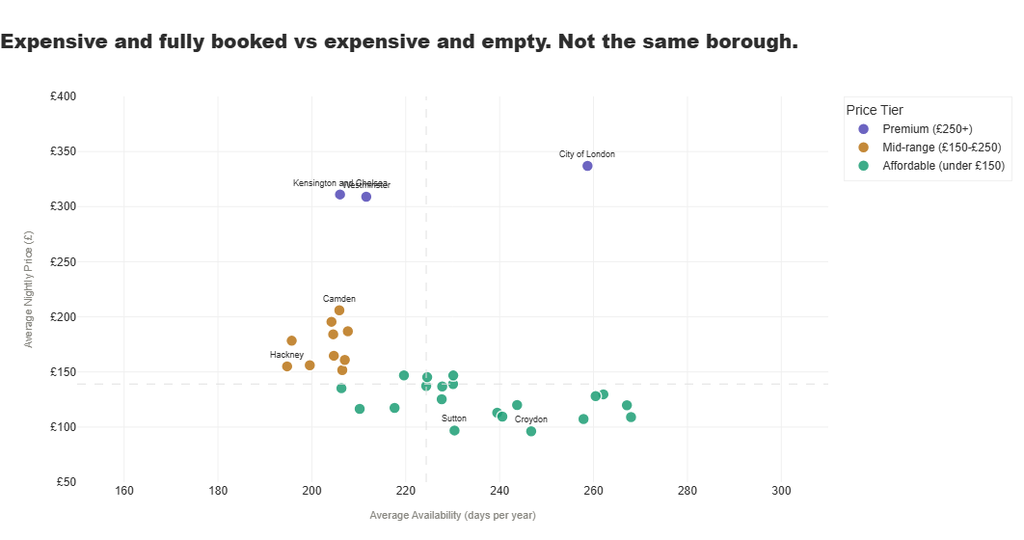

```
Chart 4 saved.
```

```python
# === CHART 4: THE SCARCITY PREMIUM — SIMPLIFIED ===

scarcity_summary = df_listings.groupby('neighbourhood').agg(
    avg_price        = ('price', 'mean'),
    avg_availability = ('availability_365', 'mean'),
    listing_count    = ('price', 'count')
).reset_index().round(2)

# Save for Tableau
scarcity_summary.to_csv('data/scarcity_summary.csv', index=False)

# Price tier for colour
def price_tier(p):
    if p >= 250:
        return 'Premium (£250+)'
    elif p >= 150:
        return 'Mid-range (£150-£250)'
    else:
        return 'Affordable (under £150)'

scarcity_summary['price_tier'] = scarcity_summary['avg_price'].apply(price_tier)

tier_colors = {
    'Premium (£250+)'        : '#534AB7',
    'Mid-range (£150-£250)'  : '#BA7517',
    'Affordable (under £150)': '#1D9E75'
}

# Outlier labels only
outlier_boroughs = [
    'Westminster', 'Kensington and Chelsea', 'City of London',
    'Croydon', 'Sutton', 'Camden', 'Hackney'
]

fig = go.Figure()

for tier, color in tier_colors.items():
    tier_data = scarcity_summary[
        scarcity_summary['price_tier'] == tier].copy()

    fig.add_trace(go.Scatter(
        x=tier_data['avg_availability'],
        y=tier_data['avg_price'],
        mode='markers',
        name=tier,
        marker=dict(
            size=12,
            color=color,
            opacity=0.85,
            line=dict(color='white', width=1.5)
        ),
        hovertemplate=(
            "<b>%{customdata}</b><br>"
            "Avg Availability: %{x:.0f} days/year<br>"
            "Avg Price: £%{y:,.0f}<extra></extra>"
        ),
        customdata=tier_data['neighbourhood']
    ))

# Label outliers only
for _, row in scarcity_summary.iterrows():
    if row['neighbourhood'] in outlier_boroughs:
        fig.add_annotation(
            x=row['avg_availability'],
            y=row['avg_price'],
            text=row['neighbourhood'],
            showarrow=False,
            font=dict(size=9, color='#2d2d2d', family='Arial'),
            xshift=0,
            yshift=12
        )

# Quadrant lines
mid_availability = scarcity_summary['avg_availability'].median()
mid_price = scarcity_summary['avg_price'].median()

fig.add_shape(type='line',
    x0=mid_availability, x1=mid_availability,
    y0=50, y1=400,
    line=dict(color='#e0e0e0', width=1, dash='dash'))

fig.add_shape(type='line',
    x0=150, x1=310,
    y0=mid_price, y1=mid_price,
    line=dict(color='#e0e0e0', width=1, dash='dash'))

fig.update_layout(
    title=dict(
        text='Expensive and fully booked vs expensive and empty. Not the same borough.',
        font=dict(size=20, color='#2d2d2d', family='Arial Black'),
        x=0, pad=dict(b=20)
    ),
    xaxis=dict(
        title=dict(
            text='Average Availability (days per year)',
            font=dict(size=11, color='#888780')
        ),
        gridcolor='#f0f0f0',
        range=[150, 310]
    ),
    yaxis=dict(
        title=dict(
            text='Average Nightly Price (£)',
            font=dict(size=11, color='#888780')
        ),
        gridcolor='#f0f0f0',
        tickprefix='£',
        range=[50, 400]
    ),
    plot_bgcolor='white',
    paper_bgcolor='white',
    height=560,
    margin=dict(l=80, r=40, t=100, b=60),
    font=dict(family='Arial', color='#2d2d2d'),
    legend=dict(
        title='Price Tier',
        bordercolor='#f0f0f0',
        borderwidth=1
    ),
    hoverlabel=dict(
        bgcolor='grey',
        bordercolor='#f0f0f0',
        font=dict(size=12, family='Arial'),
        namelength=-1
    )
)

fig.write_html('charts/chart4_scarcity_premium.html')
fig.write_image('charts/chart4_scarcity_premium.png',
                width=1200, height=560, scale=2)
fig.show()
print("Chart 4 saved.")
```

## The Solo Host vs The Empire Builder

Not everyone on Airbnb is renting out their spare room while they visit family for the weekend. London's short term rental market has two very different host profiles operating in the same space with very different pricing strategies and very different relationships with demand.

The solo host has one listing. It is probably their home or a property they own and manage personally. The pricing reflects what they think their space is worth, the availability reflects their actual life, and the reviews reflect a personal investment in the guest experience that a professional operator cannot always replicate at scale.

The empire builder has ten, twenty, sometimes fifty listings. This is a business. The pricing is optimised, the availability is managed, and the operation runs with the efficiency of someone who has done this enough times to know exactly what the market will bear. Whether they charge more or less than the solo host, and whether their listings are more or less available, tells you something important about how professionalised London's short term rental market has become.

```
Host summary saved for Tableau.
                      host_type  avg_price  median_price  avg_availability  listing_count  avg_reviews
  Empire Builder (20+ listings)     264.36        182.00            221.87          12094        19.41
Medium Operator (6-20 listings)     209.15        156.00            228.86          11691        26.84
  Small Operator (2-5 listings)     155.74        110.00            215.14          15467        33.94
          Solo Host (1 listing)     161.08        120.00            199.92          21525        26.68
```

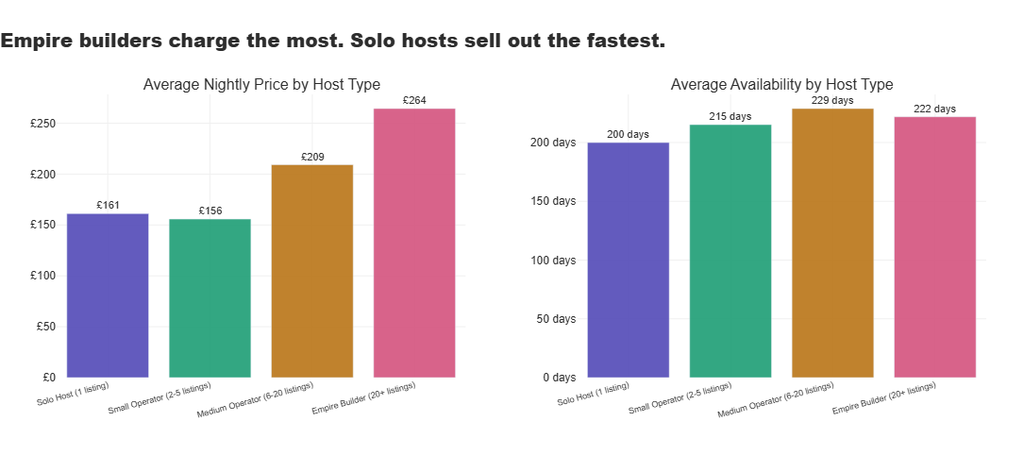

```
Chart 5 saved.
```

```python
# === CHART 5: SOLO HOST VS EMPIRE BUILDER ===

def host_type(count):
    if count == 1:
        return 'Solo Host (1 listing)'
    elif count <= 5:
        return 'Small Operator (2-5 listings)'
    elif count <= 20:
        return 'Medium Operator (6-20 listings)'
    else:
        return 'Empire Builder (20+ listings)'

df_listings['host_type'] = df_listings[
    'calculated_host_listings_count'].apply(host_type)

host_summary = df_listings.groupby('host_type').agg(
    avg_price        = ('price', 'mean'),
    median_price     = ('price', 'median'),
    avg_availability = ('availability_365', 'mean'),
    listing_count    = ('price', 'count'),
    avg_reviews      = ('number_of_reviews', 'mean')
).reset_index().round(2)

# Save for Tableau
host_summary.to_csv('data/host_summary.csv', index=False)
print("Host summary saved for Tableau.")
print(host_summary.to_string(index=False))

host_order = [
    'Solo Host (1 listing)',
    'Small Operator (2-5 listings)',
    'Medium Operator (6-20 listings)',
    'Empire Builder (20+ listings)'
]

host_colors = {
    'Solo Host (1 listing)'          : '#534AB7',
    'Small Operator (2-5 listings)'  : '#1D9E75',
    'Medium Operator (6-20 listings)': '#BA7517',
    'Empire Builder (20+ listings)'  : '#D4537E'
}

host_summary['host_type'] = pd.Categorical(
    host_summary['host_type'], categories=host_order, ordered=True)
host_summary = host_summary.sort_values('host_type')

fig = make_subplots(
    rows=1, cols=2,
    subplot_titles=[
        'Average Nightly Price by Host Type',
        'Average Availability by Host Type'
    ],
    horizontal_spacing=0.12
)

# Price chart
fig.add_trace(go.Bar(
    x=host_summary['host_type'],
    y=host_summary['avg_price'],
    marker=dict(
        color=[host_colors[h] for h in host_summary['host_type']],
        opacity=0.9
    ),
    text=[f"£{v:,.0f}" for v in host_summary['avg_price']],
    textposition='outside',
    textfont=dict(size=11, family='Arial'),
    showlegend=False,
    hovertemplate=(
        "<b>%{x}</b><br>"
        "Avg Price: £%{y:,.0f}<extra></extra>"
    )
), row=1, col=1)

# Availability chart
fig.add_trace(go.Bar(
    x=host_summary['host_type'],
    y=host_summary['avg_availability'],
    marker=dict(
        color=[host_colors[h] for h in host_summary['host_type']],
        opacity=0.9
    ),
    text=[f"{v:.0f} days" for v in host_summary['avg_availability']],
    textposition='outside',
    textfont=dict(size=11, family='Arial'),
    showlegend=False,
    hovertemplate=(
        "<b>%{x}</b><br>"
        "Avg Availability: %{y:.0f} days<extra></extra>"
    )
), row=1, col=2)

fig.update_layout(
    title=dict(
        text='Empire builders charge the most. Solo hosts sell out the fastest.',
        font=dict(size=20, color='#2d2d2d', family='Arial Black'),
        x=0, pad=dict(b=20)
    ),
    plot_bgcolor='white',
    paper_bgcolor='white',
    height=500,
    margin=dict(l=60, r=40, t=100, b=100),
    font=dict(family='Arial', color='#2d2d2d'),
    hoverlabel=dict(
        bgcolor='grey',
        bordercolor='#f0f0f0',
        font=dict(size=12, family='Arial'),
        namelength=-1
    )
)

fig.update_xaxes(
    gridcolor='#f0f0f0',
    tickfont=dict(size=9, family='Arial'),
    tickangle=-15
)
fig.update_yaxes(gridcolor='#f0f0f0')
fig.update_yaxes(tickprefix='£', row=1, col=1)
fig.update_yaxes(ticksuffix=' days', row=1, col=2)

fig.write_html('charts/chart5_host_types.html')
fig.write_image('charts/chart5_host_types.png',
                width=1200, height=500, scale=2)
fig.show()
print("Chart 5 saved.")
```

Empire builders charge £264 on average. Solo hosts charge £161. The assumption that personal, character-filled listings command a premium over professionally managed ones is not what the London Airbnb data says. The professional operator has figured out the pricing optimisation. The solo host has not, or has not tried to.

But the availability chart tells the other half of the story. Solo hosts average 200 available days per year, the lowest of any host category. Empire builders average 222 days. The solo host listing is harder to book not because the host is more selective but because the demand is absorbing the supply faster. People are choosing the personal listing at £161 and booking it out. People are choosing the empire builder listing at £264 and finding it still available.

The Christmas traveller looking for somewhere to stay in London in December faces this choice in every borough. The characterful flat managed by someone who lives nearby and leaves a bottle of wine on the counter. Or the professionally managed apartment with the keypad entry and the laminated instruction sheet. The data says the first one costs less and is harder to find. The second one costs more and is usually still there when you look.

## So. What Does Christmas Actually Cost In London?

It depends entirely on where you stay, who you book with, and how far in advance you start looking. Which the data suggests should be August. Not December. August.

Westminster charges £309 on average. Croydon charges £96. These are not two different cities. They are two stops on the same tube line and the price difference between them is the price of proximity to the fairy lights, the markets, the ice rinks, and the particular kind of London that the world flies in to experience every December. The Christmas premium is not a myth. It is a postcode.

The search interest data makes one thing very clear. Demand for London at Christmas has grown every single year in this dataset. 2025 hit a Google Trends score of 100, the highest ever recorded for this search term. The world is not getting less interested in spending Christmas in London. It is getting more interested, earlier, with more intention. The hosts know this. The pricing reflects it. The availability data confirms that the best listings in the best boroughs absorb that demand faster than any other category in this dataset.

The empire builder charges more. The solo host sells out faster. The premium borough is expensive and relatively scarce. The affordable borough is cheap and always available. None of this is surprising in isolation. What the data makes visible is the full shape of the market at once, every borough, every host type, every price point, laid out clearly enough that the Christmas traveller and the hospitality brand investing in London short term rentals can make a genuinely informed decision.

The fairy lights are not in the data. But everything else is.

**Analyst:** Trupthi Raj **GitHub:** github.com/trupthiraj **Tableau:** public.tableau.com/app/profile/trupthi.raj/vizzes